# RNAseq DESeq2 Time Course

Corey Hayford & Darren Tyson

November 2018 through January 2024

## Overview

This is a pipeline for differential analysis of RNASeq data from SKMEL5 sublines using DESeq2 statistical package. Three sublines: SC01 (*regressing*), SC07 (*stationary*) and SC10 (*expanding*) were analyzed for gene expression differences. In addition, time course changes in 8 µM PLX4720 were also performed for each subline. Time points are: 0, 3d, 8d. The differential analysis will be performed based on the contrasts defined below. General steps for the analysis are:

### 1. Read counts table:

- Could be read directly as a csv/txt file.
- Alignment and read counts could be done within R environment to create read counts table.
1. Define working directory, load the required libraries.
2. Get read counts table. Read the raw counts file processed by featureCounts. The fastq files were aligned with HiSat2, and the read counts were obtained using featureCounts of Rsubread packages.

```r
pkgs <- c("BiocManager","DESeq2","org.Hs.eg.db","clusterProfiler","HDO.db",
          "pheatmap","ggnewscale","PoiClaClu","enrichR","gtable","Rmisc")
source("getReqdPkgs.r")
getReqdPkgs(pkgs)
```

```
'getOption("repos")' replaces Bioconductor standard repositories, see 'help("repositories", package = "BiocManager")' for details.
Replacement repositories:
    CRAN: https://cran.rstudio.com/
All required CRAN and BioC packages have previously been installed
```

```r
suppressPackageStartupMessages(expr={
    library(plyr)
    library(dplyr)
    library(ggplot2)
    library(ggnewscale)
    library(reshape2)
    library(DESeq2)
    library(ggrepel)
    library(pheatmap)
    library(org.Hs.eg.db)
    library(clusterProfiler)
    library("RColorBrewer")
    library(enrichR)
    library(biomaRt)
    library(Rmisc)
})
SAVEFILES <- FALSE

SAVEPATH <- file.path("~/Desktop/melanoma_DESeq2")
if(!dir.exists(SAVEPATH) & SAVEFILES) dir.create(SAVEPATH)
```

```r
countdata <- read.csv("../data/featureCounts_matrix_all.csv", header=T, sep=",")

#Rename columns
cols <- c("ensembl_gene_id", "SC01_day0_rep1", "SC01_day0_rep2", "SC01_day0_rep3",
          "SC01_day3_rep1", "SC01_day3_rep2", "SC01_day3_rep3",
          "SC01_day8_rep1", "SC01_day8_rep2", "SC01_day8_rep3",
          "SC07_day0_rep1", "SC07_day0_rep2", "SC07_day0_rep3",
          "SC07_day3_rep1", "SC07_day3_rep2", "SC07_day3_rep3",
          "SC07_day8_rep1", "SC07_day8_rep2", "SC07_day8_rep3",
          "SC10_day0_rep1", "SC10_day0_rep2", "SC10_day0_rep3",
          "SC10_day3_rep1", "SC10_day3_rep2", "SC10_day3_rep3",
          "SC10_day8_rep1", "SC10_day8_rep2", "SC10_day8_rep3")
names(countdata) <- cols
mart <- useDataset("hsapiens_gene_ensembl", mart = useEnsembl("ensembl", mirror="useast"))
```

```
Ensembl site unresponsive, trying asia mirror
Ensembl site unresponsive, trying www mirror
```

```r
genes <- countdata$ensembl_gene_id
G_list <- getBM(attributes= c("ensembl_gene_id","hgnc_symbol"),
                filters= "ensembl_gene_id",
                values=genes,
                mart=mart)

GE_data <- merge(countdata, G_list, by = "ensembl_gene_id")
countdata <- GE_data[, -1]
countdata <- countdata[c(28, seq(1:27))]
rownames(countdata) <- make.names(countdata$hgnc_symbol, unique = T)
countdata <- countdata[, 2:28]

# remove genes with <5 counts in all samples
countdata <- countdata[apply(countdata, 1, function(x) all(x > 5)),]
```

### 2. Convert counts table to DESeq2 object.

Convert counts table to object for DESeq2 or any other analysis pipeline. This step will require to prepare data object in a form that is suitable for analysis in DESeq2 pipeline: we will need the following to proceed:

- countdata: a table with the read/fragment counts.
- coldata: a table with information about the samples.

Using the matrix of counts and the sample information table, we need to construct the DESeqDataSet object, for which we will use DESeqDataSetFromMatrix…..

#### 2.1. Define the samples and treatment conditions.

```r
coldata <- data.frame(cell=rep(rep(c("SC01", "SC07","SC10"), each=3)),
                      treatment=rep(rep(c("0", "3", "8"), each=3), each=3))

coldata$group <- factor(paste(coldata$cell, coldata$treatment, sep="."))
```

#### 2.2. construct the DESeqDataSet object from the matrix of counts and the sample information table.

Described above are: countdata- raw counts, coldata: sample information table.

```r
dds <- DESeqDataSetFromMatrix(countData = countdata,
                              colData = coldata,
                              design = ~ cell + treatment + cell:treatment)
```

### 3. Exploratory analysis and visualization.

There are two separate steps in the workflow; the one which involves data transformations in order to visualize sample relationships and the second step involves statistical testing methods which requires the original raw counts.

#### 3.1. Pre-filtering and normalization.

Pre-filtering and normalization is required to remove low-expressed genes and log normalize.

```r
dds2 <- dds[rowSums(counts(dds)) > 18, ] # remove rows with minimum of 2 read per condition

# log normalize
rld <- rlog(dds2, blind = FALSE)
```

#### 3.2. Visualize sample-to-sample distances.

We use Principal Component Analysis (PCA) to visualize relationships between samples.

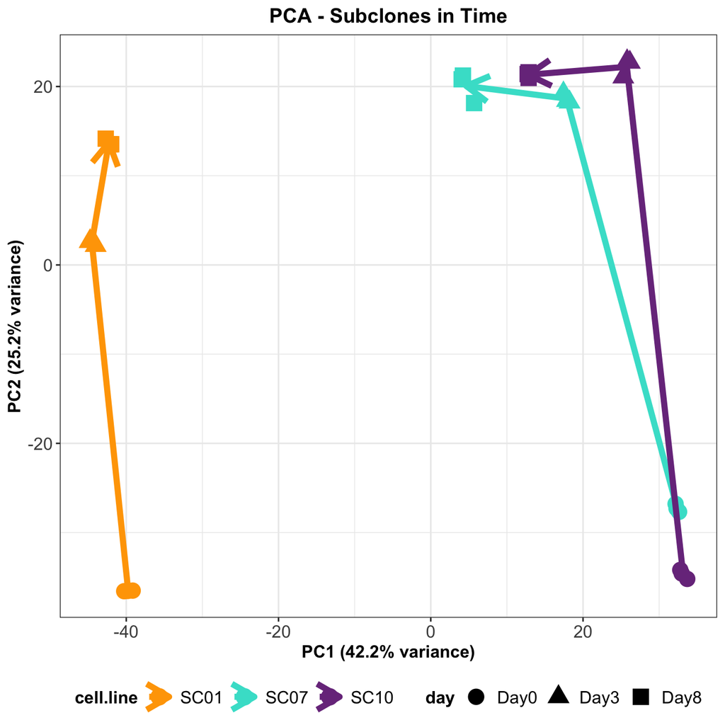

```r
## Use prcomp function
# Colored by cell line, shape by time point, lines connecting time
pca_DEseq <- prcomp(t(assay(rld)))
pca_DEseq_perc <- round(100*pca_DEseq$sdev^2/sum(pca_DEseq$sdev^2),1)
pca_DEseq_df <- data.frame(PC1 = pca_DEseq$x[,1],
                           PC2 = pca_DEseq$x[,2],
                           sample = colnames(assay(rld)),
                           cell.line = rep(c("SC01", "SC07", "SC10"), each = 9),
                           day = rep(c("Day0", "Day3", "Day8"), each = 3),
                           replicate = rep(c("Rep1", "Rep2", "Rep3"), times=9))

pca_DEseq_means <- ddply(pca_DEseq_df, .(cell.line, day), summarise, meanPC1 = mean(PC1), meanPC2 = mean(PC2))

mycolors <- c("orange","turquoise","mediumorchid4")
ggplot(pca_DEseq_df, aes(PC1,PC2, color = cell.line)) +
  geom_point(aes(shape = day), size=5) +
  geom_path(data = pca_DEseq_means,
            aes(x=meanPC1, y=meanPC2,
                color=cell.line), arrow = arrow(),
            linewidth = 2) +
  scale_colour_manual(values=mycolors) +
  labs(x=paste0("PC1 (",pca_DEseq_perc[1],"% variance)"), y=paste0("PC2 (",pca_DEseq_perc[2],"% variance)")) +
  theme_bw() + ggtitle("PCA - Subclones in Time") +
  theme(legend.text = element_text(size = 12),
        plot.title = element_text(size = 14,
                                  hjust = 0.5,
                                  face = "bold"),
        axis.text=element_text(size=12),
        legend.title = element_text(size=12,face="bold"),
        legend.position = "bottom",
        axis.title=element_text(size=12, face="bold"))
```

```r
if(SAVEFILES) ggplot2::ggsave(filename=file.path(SAVEPATH,"Subclones_PCA.pdf"), device="pdf", width=7, height=7)
```

### 4. Differential Expression Analysis.

Always make sure to use the unnormalized raw counts for this. We will use DESeq function to perform differential analysis between samples; Unless specified, the analysis is between the last group and the first group. Different comparison can be done using ‘contrast’ argument. Steps involved underneath:

1. estimation of size factors (controls for differences in sequencing depth of the samples)
2. estimation of dispersion values for each gene,
3. fitting a generalized linear model

#### 4.1. Running the differential expression pipeline.

```r
design(dds2) = ~ cell + treatment + cell:treatment
dds <- DESeq(dds2, test = "LRT", reduced = ~ cell + treatment)
```

#### 4.2. Building the results table.

By default, results will extract the estimated log2 fold changes and p values for the last variable in the design formula. If there are more than 2 levels for this variable, results will extract the results table for a comparison of the last level over the first level.

```r
# Esimate the differences between groups by: # a) Lowering the FDR (padj) or (b) raise the log2 fold change.
# resultsNames(dds)

# alpha = FDR adjusted p value cutoff
res <- results(dds, alpha = 0.001)
# summary(res)
resOrdered <- res[order(res$pvalue),]
rdata <- as.data.frame(res)
```

### Differential expression: days 0 to 8

Significant log2 fold change is 1.585 (== 3-fold change in log2 space).

```r
res_0to8d <- results(dds, name="treatment_8_vs_0", cooksCutoff = 0.99,
                     independentFiltering = TRUE, alpha = 0.05, pAdjustMethod = "BH")

# order results table by the smallest adjusted p value:
res_0to8d <- res_0to8d[order(res_0to8d$padj),]
results_0to8d <- as.data.frame(res_0to8d)

results_0to8d <- mutate(results_0to8d, sig=ifelse(results_0to8d$padj<0.05 & results_0to8d$log2FoldChange > 1.585, "Upregulated",
                                                  ifelse(results_0to8d$padj<0.05 & results_0to8d$log2FoldChange < -1.585,
                                                         "Downregulated", "Not Significant")))

row.names(results_0to8d) <- row.names(res_0to8d)

DEgenes_0to8d <- results_0to8d[which(abs(results_0to8d$log2FoldChange) > log2(1.5) & results_0to8d$padj < 0.05),]

if(SAVEFILES) write.csv(DEgenes_0to8d, file=file.path(SAVEPATH,"DEgenes_0to8d.csv"))
```

```r
upreg_genes <- subset(results_0to8d, padj<0.05 & log2FoldChange>2)
downreg_genes <-subset(results_0to8d, padj<0.05 & log2FoldChange<(-2))

geneList_up <- as.vector(upreg_genes$log2FoldChange)
names(geneList_up) <- rownames(upreg_genes)
geneList_down <- as.vector(downreg_genes$log2FoldChange)
names(geneList_down) <- rownames(downreg_genes)

genes_up <- as.vector(rownames(upreg_genes))
genes_down <- as.vector(rownames(downreg_genes))
# names(geneList) <- rownames(results_0to8d)
genes_up_ENTREZID <- bitr(genes_up, fromType = "SYMBOL", toType = "ENTREZID", OrgDb = org.Hs.eg.db)$ENTREZID
genes_down_ENTREZID <- bitr(genes_down, fromType = "SYMBOL", toType = "ENTREZID", OrgDb = org.Hs.eg.db)$ENTREZID
# Group GO
ggo_up <- clusterProfiler::groupGO(gene  = genes_up_ENTREZID,
                                OrgDb    = org.Hs.eg.db,
                                ont      = "BP",
                                level    = 3,
                                readable = TRUE)
ggo_up_df <- as.data.frame(ggo_up)
ggo_up_df <- ggo_up_df[order(-ggo_up_df$Count),]

ggo_down <- clusterProfiler::groupGO(gene = genes_down_ENTREZID,
                                 OrgDb    = org.Hs.eg.db,
                                 ont      = "BP",
                                 level    = 3,
                                 readable = TRUE)

# GO over-representation test
ego_genesUp <- clusterProfiler::enrichGO(gene  = genes_up_ENTREZID,
                                 OrgDb         = org.Hs.eg.db,
                                 ont           = "BP",
                                 pAdjustMethod = "BH",
                                 pvalueCutoff  = 0.05,
                                 qvalueCutoff  = 0.05,
                                 readable      = TRUE)

ego_genesDown <- clusterProfiler::enrichGO(gene  = genes_down_ENTREZID,
                                 OrgDb         = org.Hs.eg.db,
                                 ont           = "BP",
                                 pAdjustMethod = "BH",
                                 pvalueCutoff  = 0.05,
                                 qvalueCutoff  = 0.05,
                                 readable      = TRUE)
```

### Plot GO enrichment

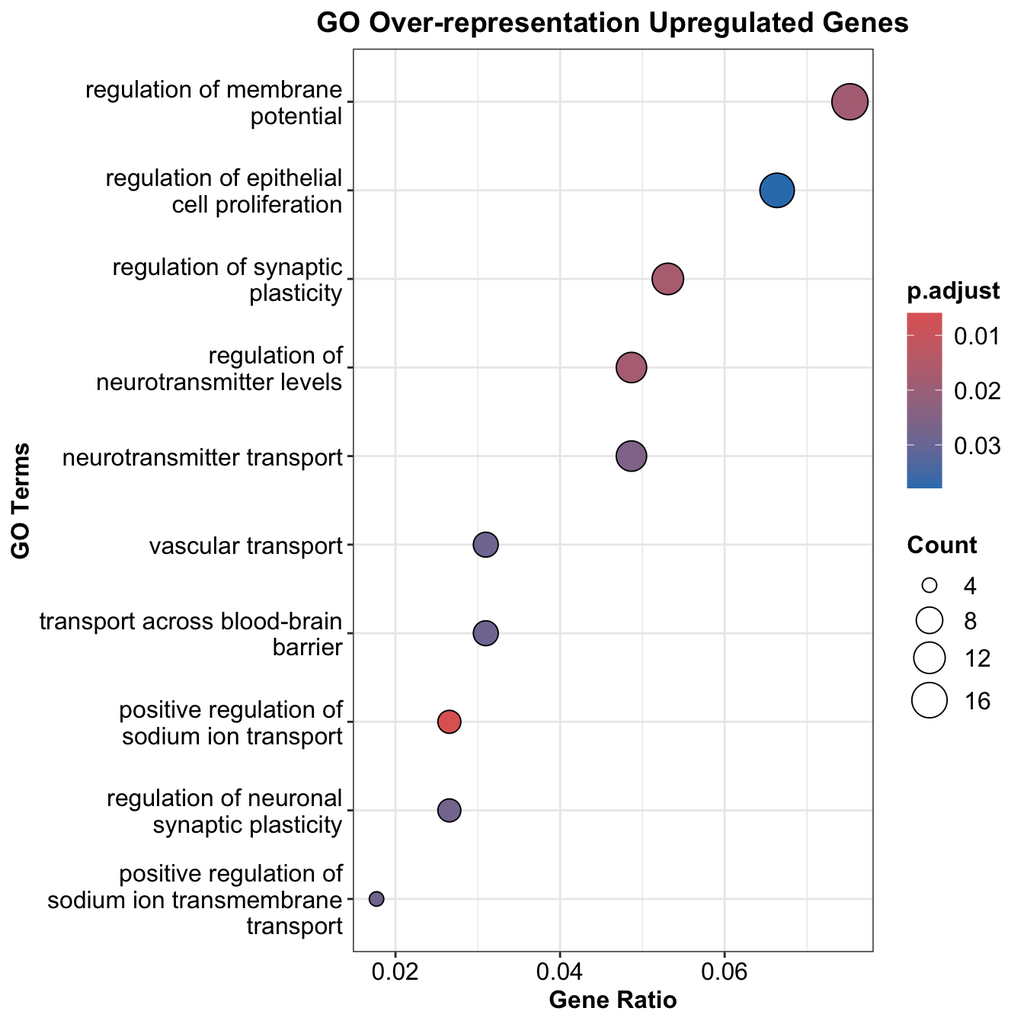

```r
enrichplot::dotplot(ego_genesUp) + ggtitle("GO Over-representation Upregulated Genes") +
  labs(x="Gene Ratio", y="GO Terms") +
  theme(legend.text = element_text(size = 12),
        plot.title = element_text(size = 14, hjust = 0.5, face = "bold"),
        axis.text=element_text(size=12),
        legend.title = element_text(size=12,face="bold"),
        axis.title=element_text(size=12, face="bold"))
```

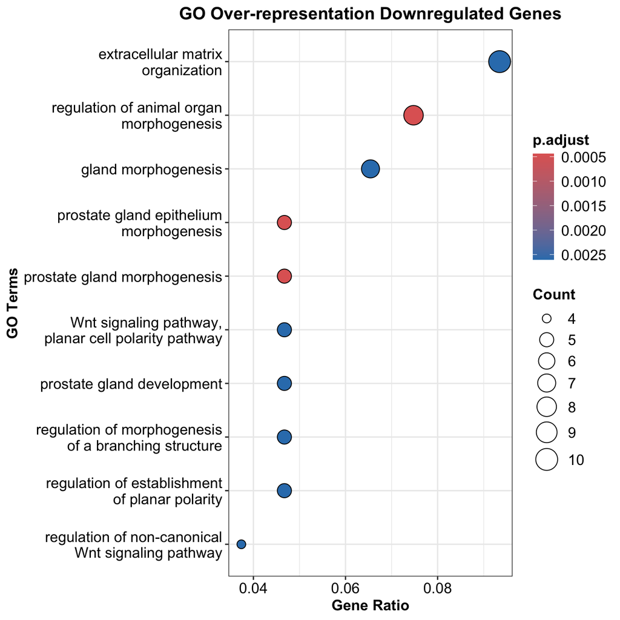

```r
enrichplot::dotplot(ego_genesDown) + ggtitle("GO Over-representation Downregulated Genes") +
  labs(x="Gene Ratio", y="GO Terms") +
  theme(legend.text = element_text(size = 12),
        plot.title = element_text(size = 14, hjust = 0.5, face = "bold"),
        axis.text=element_text(size=12),
        legend.title = element_text(size=12,face="bold"),
        axis.title=element_text(size=12, face="bold"))
```

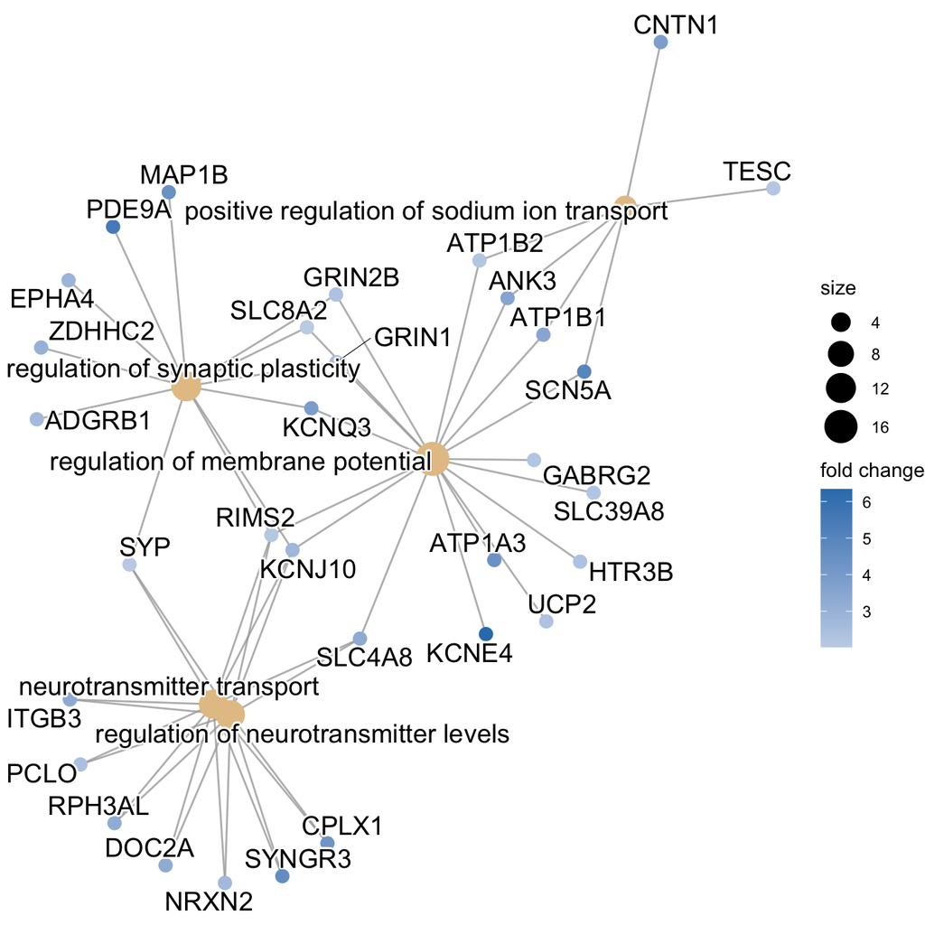

```r
enrichplot::cnetplot(ego_genesUp, categorySize="pvalue", color.params = list(foldChange = geneList_up))
```

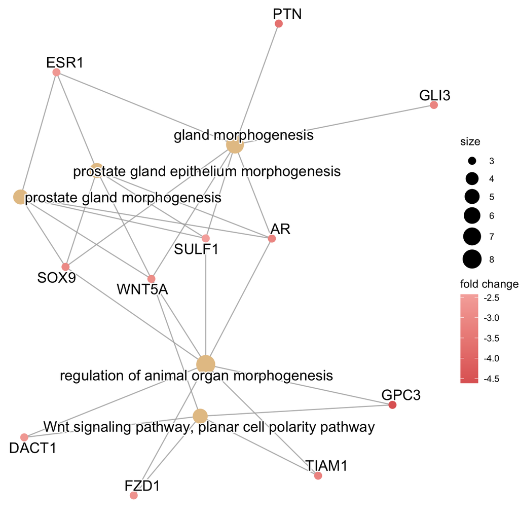

```r
enrichplot::cnetplot(ego_genesDown, categorySize="pvalue", color.params = list(foldChange = geneList_down))
```

```r
ego_genesUp_df <- as.data.frame(ego_genesUp)
egoUp <- ego_genesUp_df[order(-ego_genesUp_df$Count),]
egoUp_genes <- strsplit(egoUp$geneID, "/", fixed=TRUE)
```

```r
geneList_all <- as.vector(results_0to8d$log2FoldChange)
genes_HGCN <- rownames(results_0to8d)
genes_ENTREZID <- bitr(genes_HGCN, fromType = "SYMBOL", toType = "ENTREZID", OrgDb = org.Hs.eg.db)$ENTREZID
```

```
Warning: 10.54% of input gene IDs are fail to map...
```

```r
names(geneList_all) <- genes_ENTREZID

gene_df <- data.frame(Entrez=names(geneList_all), HGNC=genes_HGCN, FC=geneList_all)
gene_df <- gene_df[abs(gene_df$FC) > 1,]
gene_df$group <- "upregulated"
gene_df$group[gene_df$FC < 0] <- "downregulated"
gene_df$othergroup <- "A"
gene_df$othergroup[abs(gene_df$FC) > 2] <- "B"

formula_res <- compareCluster(Entrez~group+othergroup, data=gene_df, fun="enrichKEGG")
```

### Clustering

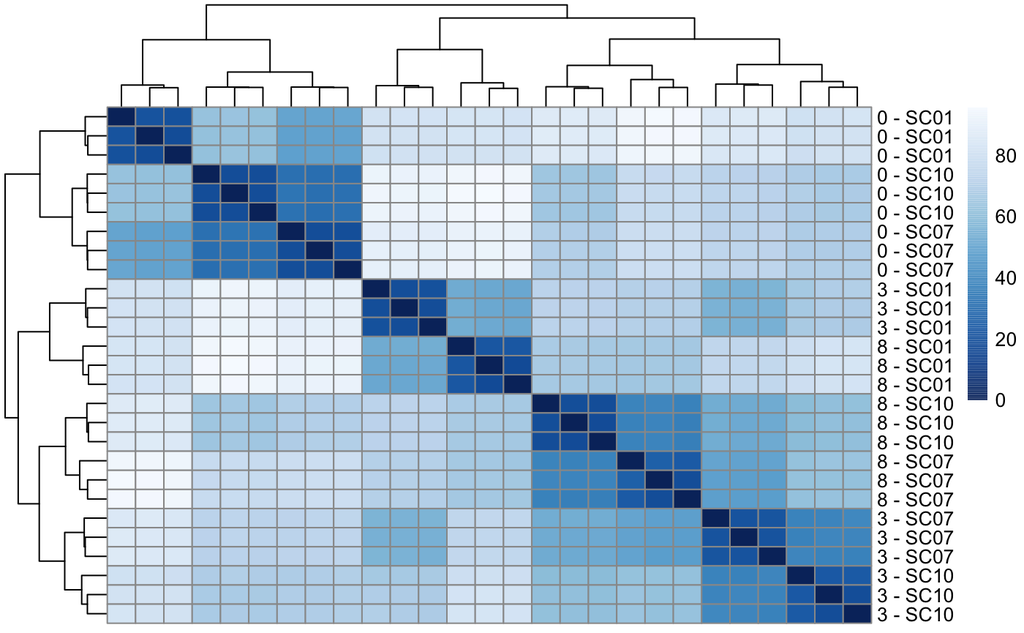

```r
# log normalize
rld2 <- rlog(dds, blind = FALSE)

sampleDists <- dist(t(assay(rld2)))

sampleDistMatrix <- as.matrix( sampleDists )
rownames(sampleDistMatrix) <- paste(rld2$treatment, rld2$cell, sep = " - " )
colnames(sampleDistMatrix) <- NULL
colors <- colorRampPalette( rev(brewer.pal(9, "Blues")) )(255)
pheatmap(sampleDistMatrix,
         clustering_distance_rows = sampleDists,
         clustering_distance_cols = sampleDists,
         col = colors)
```

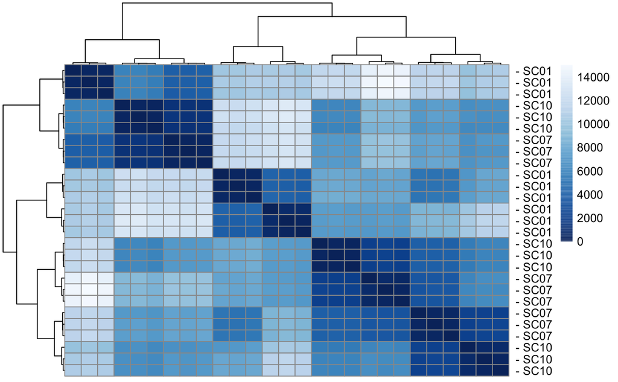

```r
poisd <- PoiClaClu::PoissonDistance(t(counts(dds)))
samplePoisDistMatrix <- as.matrix( poisd$dd )
rownames(samplePoisDistMatrix) <- paste( dds$dex, dds$cell, sep=" - " )
colnames(samplePoisDistMatrix) <- NULL
pheatmap(samplePoisDistMatrix,
         clustering_distance_rows = poisd$dd,
         clustering_distance_cols = poisd$dd,
         col = colors)
```

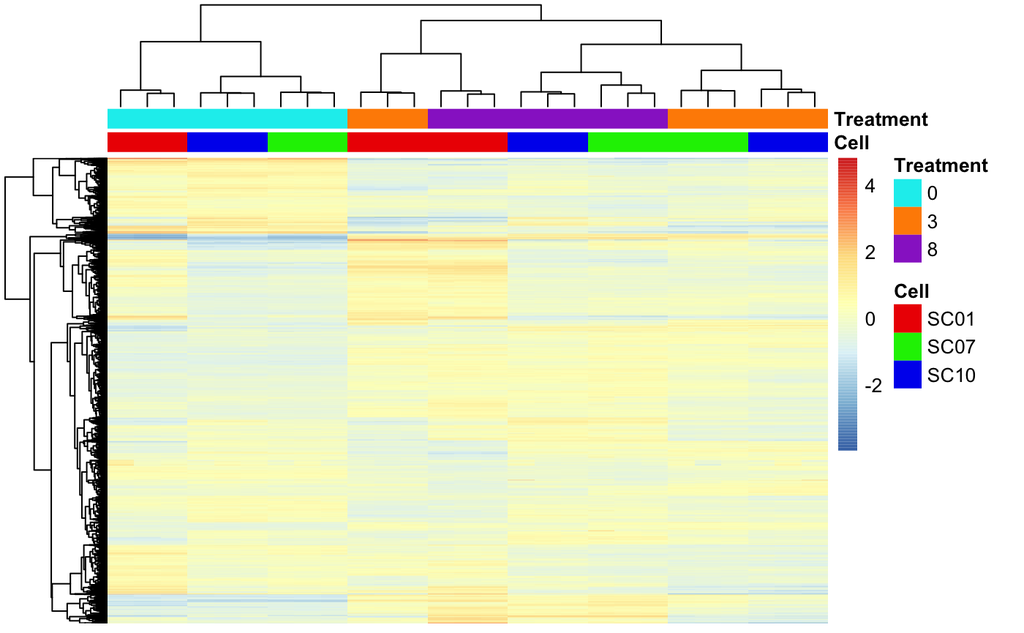

```r
topVarGenes <- head(order(rowVars(assay(rld2)), decreasing = TRUE), 5000)
mat  <- assay(rld2)[ topVarGenes, ]
mat  <- mat - rowMeans(mat)
anno <- as.data.frame(colData(rld2)[, c("cell","treatment")])
names(anno) <- c("Cell", "Treatment")
annotation_colors = list(
  Cell = c(SC01="red2", SC07="green2", SC10="blue2"),
  Treatment = c("0"="cyan2", "3"="darkorange", "8"="darkorchid"))
pheatmap(mat, annotation_col = anno, show_rownames = F, show_colnames = F,
         annotation_colors = annotation_colors)
```